# Where we are: a claim-by-claim guide to virtue, goodness, meaning, and active inference

### Written for a philosopher and a mathematician

This notebook states **every canonical claim in the current paradigm**, why we think it is plausible, what assumptions it needs, how it would be tested, what “proof” can and cannot mean, what would falsify it, and where the evidence currently stands.

The central proposal is:

> A virtue is a selectively metastable calibration of semantic-pragmatic meaning to phenotype-relative goodness, enacted through active-inference dynamics and embedded in social systems whose shared meanings and joint consequences must be tested.

**Essential caution.** Mathematical proof shows what follows from encoded assumptions. Simulation shows what a constructed model can do. Empirical evidence estimates what happens in a target population. Normative argument defends what ought to count. None of these substitutes for the others.

**Pictures-first route.** You do not need to read twenty claim cards before seeing the research programme. Jump directly to the experiment genealogy, visual experiment atlas, theorem inventory, or roadmap and stopping rules. The atlas distinguishes measured simulation results from pedagogical animations and from planned designs that have not run.

## 1. The thesis in one diagram

The upper loop is descriptive and computational. The moral bridge is an explicit additional layer: active inference does not manufacture it.

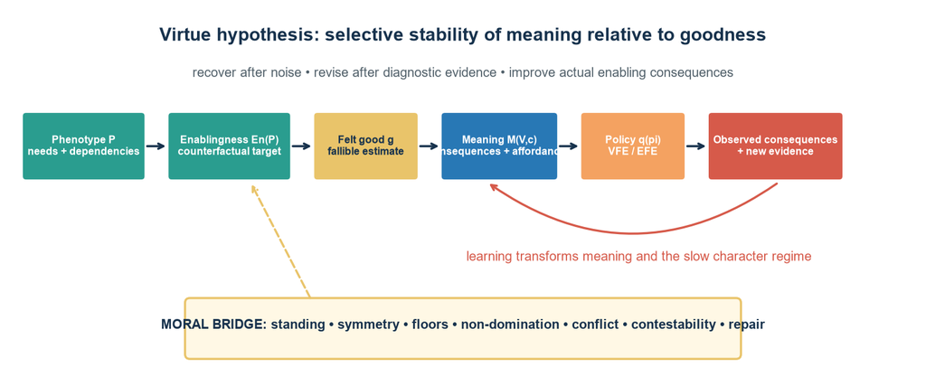

## 2. What counts as a proof here?

The word **prove** is dangerously ambiguous across this project. The following standards are complementary, not rungs on one scale.

| Standard | What it establishes | Required instrument | What it cannot establish |
| --- | --- | --- | --- |
| Conceptual | A distinction or implication follows from defended meanings | Counterexamples, conceptual analysis, non-circular definitions | Does not show the world instantiates it |
| Mathematical | A conclusion follows from explicit formal assumptions | Lean theorem, analytic derivation, verified finite enumeration | Does not validate assumptions or moral premises |
| Computational | An executable model has the stated behavior reproducibly | Seeded simulations, ablations, source hashes, adversarial cases | Does not establish humans or unique mechanism |
| Empirical | A claim predicts observations under an identified design | Preregistration, interventions, held-out prediction, uncertainty | Supports rather than deductively proves a population claim |
| Normative | Premises about standing and admissibility survive objection | Argument, reflective equilibrium, hard cases, public justification | Cannot be derived from VFE/EFE or data alone |

## 2.1 Intellectual provenance: why these are live hypotheses

The synthesis is new, but its components are not invented from nothing:

| Contribution used here | Intellectual anchor | What it supports—and does not support |
| --- | --- | --- |
| Virtue as context-sensitive skilled regulation | Aristotle's *phronesis* tradition; ecological moral expertise | Supports virtue as organized practical sensitivity, not our mathematical model |
| Metastable optimal grip on moral affordances | Hampson, Hulsey, and McGarry, provided PCS manuscript | Closest conceptual prior art for virtue as metastable grip; does not supply goodness calibration or the experiments |
| VFE/EFE perception and policy dynamics | [Discrete active-inference synthesis](https://pmc.ncbi.nlm.nih.gov/articles/PMC7732703/) | Supplies a process formalism, not moral premises |
| Formulation dependence of EFE decompositions | [Millidge, Tschantz & Buckley](https://direct.mit.edu/neco/article/33/2/447/95615/Whence-the-Expected-Free-Energy) | Requires us to declare the root functional and assumptions |
| Information valuable for maintaining a system | [Kolchinsky & Wolpert](https://doi.org/10.1098/rsif.2018.0625) | Motivates viability-relative semantic information; does not establish moral goodness |
| Shared anticipatory organization without identical belief | [Albarracin et al., Shared Protentions](https://doi.org/10.3390/e26040303) | Grounds heterogeneous shared anticipation |
| Alignment as mutual processability | [Takahashi, 2026](https://arxiv.org/abs/2605.29930) | Motivates preservation under transformation; the metric is supplied by the sibling project |
| Cooperative joint action through interactive inference | [Maisto, Donnarumma & Pezzulo](https://arxiv.org/abs/2210.13113) | Supports multi-agent inferential coordination, not moral cooperation |
| Intervention rather than association for causal contribution | [Ay & Polani](https://doi.org/10.1142/S0219525908001465) | Motivates causal information-flow tests |

These sources make the components plausible. They do **not** jointly entail the paradigm. The integration still has to earn explanatory necessity experimentally.

## 2.2 How we chose the definitions

The definitions were not read directly out of active-inference equations, and they were not chosen merely because they sounded philosophically attractive. We used a seven-step decision rule:

1. **Preserve the philosophical role.** Virtue must remain a success term; meaning must explain practical consequences; cooperation must be genuinely joint.
2. **Keep the target independent of the estimate.** Actual enabling consequences cannot be defined by the feeling, preference, or posterior being calibrated.
3. **Map to generated quantities.** Operational terms must arise from model states, likelihoods, transitions, preferences, precisions, policies, observations, or explicit interventions. Labels added after the equations explain nothing.
4. **Require dissociations.** Definitions must distinguish reward from goodness, stability from virtue, dependence from cooperation, and agreement from shared meaning.
5. **Demand counterexamples and ablations.** A component earns a mechanistic role only when removing it breaks a prediction it was introduced to explain.
6. **Separate proof obligations.** Formal validity, empirical identification, and normative justification are assessed independently.
7. **Prefer the weakest adequate claim.** When evidence does not identify a unique mechanism, we downgrade from causal explanation to compatibility or description.

This procedure is why several early formulations were rejected rather than patched with extra labels.

| Construct | Rejected shortcut | Current operational definition | Decision reason |
| --- | --- | --- | --- |
| Goodness | Reward, approval, pleasure, or persistence | Counterfactual phenotype-relative enablingness | The target must remain independent of felt or preferred outcomes. |
| Felt goodness | Goodness itself | Fallible estimate of expected enablingness | Feeling can guide action while still being calibrated or mistaken. |
| Meaning | Lexical similarity or consequences alone | Context-indexed semantic-pragmatic profile | Meaning organizes predictions, affordances, affect, policy, and learning. |
| Virtue | Any stable trait or attractor | Selective calibration of meaning to goodness | Dogmatism is stable; virtue must resist noise and revise under reliable error. |
| Shared semantics | Identical beliefs or correlated actions | Reciprocal processability on relevant overlaps | Different representations can share meaning; common causes can create correlation. |
| Cooperation | A cooperate action, mutual information, or one joint EFE | Vector of joint attainment, translation, readability, complementarity, causal contribution, and per-agent coupling | Coordination can be coercive, exploitative, or externally harmful. |
| Moral goodness | Whatever minimizes VFE/EFE | Functional goodness plus an explicit normative bridge | Inference describes regulation; it does not decide standing, floors, or legitimate trade-offs. |

## 2.3 The mapping: philosophy to model to measurement

The mapping is a chain of operational hypotheses. It is not an identity claim that Aristotle already meant these equations, nor that a parameter is literally a moral faculty.

[figure not shown]

The left side supplies the independent success condition. The middle supplies felt orientation, practical meaning, and action. The return arrow supplies learning and character change.

Philosophical role

Model object

Operational reading

What the mapping contributes

Phenotype / form of life

[figure not shown]

Viability bounds, capacities, needs, horizons, dependencies

Indexes whose functioning is evaluated

Functional goodness

Counterfactual change under removal or scrambling

Independent calibration target

Felt goodness

EFE contrast or learned embodied prediction

Fallible practical heuristic

Situated construal

Fast semantic weights

What the present context appears to mean

Character / disposition

Slow learned centre

Cross-situational persistence and retained learning

Evidence sensitivity

Observation/evidence precision

Resistance to noise without indifference to evidence

Practical relevance

Diagnosticity weighting

Whether evidence should revise the slow regime

Context sensitivity

[figure not shown]

Context-feature interactions

Why the same virtue may reverse its action

Explicit attraction candidate

[figure not shown]

Fast pull toward slow centre

Candidate mechanism; not necessary in current ablation

Practical meaning

[figure not shown]

Consequences, policies, affordances, affect, cue mappings, beliefs, precision

Content of the virtue for agent i in context c

Action selection

[figure not shown]

Policy posterior under a declared EFE formulation

Contextual pragmatic enactment

Shared meaning

[figure not shown]

Held-out translation of anticipatory streams

Compatibility without identical beliefs

Cooperative organization

[figure not shown]

plus interventions

Joint outcomes, causal coupling, readability, complementarity

Joint success without collapsing agent-local effects

Moral admissibility

Bridge constraints outside bare VFE/EFE

Standing, symmetry, floors, non-domination, contestability, repair

Why functional success is not yet moral rightness

**Rule of interpretation.** A green simulation gate means “this programmed mechanism produced the declared diagnostic in this model.” It does not mean “virtue has been discovered,” “moral goodness has been derived,” or “the mechanism is uniquely necessary.”

## 3. Dependency structure

The moral and topological claims are downstream. If goodness, meaning, or shared semantics fail, topology cannot rescue the paradigm.

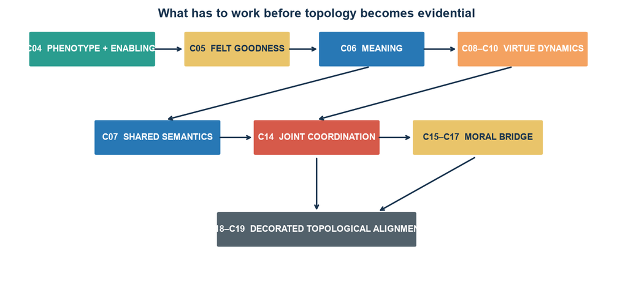

## 4. Master claim register

The 20 claims below are the canonical scope of this guide. Their detailed cards follow.

| id | group | title | status | experiment |
| --- | --- | --- | --- | --- |
| C01 | Foundations | The bearer is relational dynamics | Conceptually supported; not empirically established | V7 after V0–V6 |
| C02 | Foundations | Goodness is phenotype-relative before it is moral | Defined; finite simulation support | V1 and phenotype-reversal studies |
| C03 | Foundations | Metastability is multidimensional and morally neutral | Finite formal kernel + constructed tests | V2/V3; later stochastic proof |
| C04 | Foundations | Enablingness is counterfactual contribution | Operationalized in a finite simulation | V1; V4 affected-party extension |
| C05 | Experience and meaning | Felt goodness is a fallible embodied heuristic | Central hypothesis; simulation design recovery only | V0 human item pilot; V1 mechanism test |
| C06 | Experience and meaning | Meaning is semantic-pragmatic | Formal operationalization; linear V2 implementation | V2/V3 and V4 |
| C07 | Experience and meaning | Shared semantics is processability, not identity | Implemented in sibling repo; not yet inside V2 | V4 dyadic semantics |
| C08 | Virtue dynamics | Virtue is a success term | Canonical definition; normative bridge open | V2/V3 and V5 counterfeit virtue |
| C09 | Virtue dynamics | Virtue is selective stability relative to goodness | Robust constructed signature: 41/48 configs × 3 environments | V2/V3 complete; mechanism identification next |
| C10 | Virtue dynamics | The same virtue can reverse action across contexts | Philosophically plausible; constructed V2 support | V2/V3; human context-family study |
| C11 | Virtue dynamics | Active inference supplies pragmatics, not morality | Finite counterexample validated; EFE necessity for V2 not identified | Finite counterexample; V4 EFE ablation |
| C12 | Virtue dynamics | Practical wisdom is model governance | Novel formal hypothesis; untested | V6/V7 practical-wisdom comparison |
| C13 | Social and moral | Abstract virtue concepts and local realizations co-evolve | Conceptual model; sibling dynamics available | V6 using group-formation/social-lock-in |
| C14 | Social and moral | Cooperation is about joint distributions and interventions | Finite diagnostics implemented; integrated model not built | V4 next |
| C15 | Social and moral | Descriptive cooperation is not moral cooperation | Non-equivalence supported by finite counterexamples | V4/V5 |
| C16 | Social and moral | Moral goodness requires an explicit bridge | Explicit but open normative bridge | V5 + philosophical argument |
| C17 | Social and moral | Higher-scale stability can externalize its costs | Lean/finite counterexamples; positive model incomplete | V1 extension and V5 |
| C18 | Topology and pluralism | Bare topology is insufficient | Negative diagnosis; positive metric speculative | V7 only after V4–V6 |
| C19 | Topology and pluralism | Alignment under pluralism is preservation under transformation | Processability proxy exists; decorated theory incomplete | V4 then V7 |
| C20 | Topology and pluralism | Virtue ethics, consequentialism, and active inference play different roles | Integrative thesis; partially simulated | V2–V7 model-comparison programme |

## 5.1 Foundations

What kind of thing is being evaluated, and what functional goodness means.

### C01 — The bearer is relational dynamics

**Claim.** The object of evaluation is not an isolated belief or action but an agent-in-context dynamical organization that generates perception, feeling, policy, action, and learning.

**Why we think so.** Equal outputs can conceal different responses to evidence, pressure, and perturbation. Alignment therefore has to concern the process that produces and revises outputs.

**Formal object.**

[figure not shown]

**Assumptions / dependencies.** A state description can be chosen without making the thesis vacuous; contexts and learning variables are observable or identifiable enough to compare. See dependency graph and stated assumptions

**How we test it.** Match agents on current outputs, perturb evidence or context, and test whether dynamical descriptors predict divergent future trajectories beyond output baselines.

**What “proof” requires.** A representation theorem or identifiability result must state which changes of coordinates preserve the bearer. Empirical superiority requires held-out predictive comparison.

**What would count against it.** If current-output models predict perturbation responses as well as dynamical models, the richer bearer adds no explanatory value.

**Current status.** **Conceptually supported; not empirically established**

**Experiment / next gate.** V7 after V0–V6

**Where the full argument lives.** `README; PARADIGM_PROOF_OBLIGATIONS Q1; VIRTUE_ACTIVE_INFERENCE_LITERATURE_REVIEW`

### C02 — Goodness is phenotype-relative before it is moral

**Claim.** A functional good is indexed to a phenotype understood as an embodied organization of capacities, needs, vulnerabilities, horizons, and constitutive dependencies—not as a fixed biological essence.

**Why we think so.** The same process can enable one form of life and disable another. Without an indexed bearer, claims about flourishing silently universalize one agent's needs.

**Formal object.**

[figure not shown]

**Assumptions / dependencies.** Phenotype variables can be specified independently of the outcome being praised; boundaries and needs are not chosen post hoc to save the theory. See dependency graph and stated assumptions

**How we test it.** Use matched higher-scale processes with different phenotypes and predict sign reversals in enabling contribution. V1 contains a finite constructed reversal.

**What “proof” requires.** Prove conditional statements only: given a declared P and environment class, a regime preserves specified capabilities or viability. This cannot prove moral standing.

**What would count against it.** If phenotype indexing never changes predictions, it is idle; if P can always be redescribed after failure, the account is tautological.

**Current status.** **Defined; finite simulation support**

**Experiment / next gate.** V1 and phenotype-reversal studies

**Where the full argument lives.** `MULTISCALE_GOODNESS... §§1–2; PARADIGM_PROOF_OBLIGATIONS Q2/Q6`

### C03 — Metastability is multidimensional and morally neutral

**Claim.** Attainable metastability is the capacity to remain viable, recover, adapt, retain evidence sensitivity, and preserve meaningful options; mere persistence is neither sufficient nor intrinsically good.

**Why we think so.** Dogmatism, servility, and oppressive institutions can be stable. A useful functional measure must distinguish recovery from rigidity and stability from adaptive transition.

**Formal object.**

[figure not shown]

**Assumptions / dependencies.** Components and horizons are declared in advance; conflicts are not hidden by an arbitrary scalarization. See dependency graph and stated assumptions

**How we test it.** Perturb regimes with low-quality noise and diagnostic evidence; require recovery in the first case and retained revision in the second.

**What “proof” requires.** Lean currently proves finite closure/recovery lemmas and counterexamples. A general theorem needs stochastic dynamics, invariance, and robust bounds.

**What would count against it.** If persistence alone predicts the same outcomes as the multidimensional construct, or if the components cannot be measured independently, the extension fails.

**Current status.** **Finite formal kernel + constructed tests**

**Experiment / next gate.** V2/V3; later stochastic proof

**Where the full argument lives.** `formal/TopologicalAlignment/Viability.lean; MULTISCALE_GOODNESS... §3`

### C04 — Enablingness is counterfactual contribution

**Claim.** A higher-scale process enables phenotype P to the extent that removing, scrambling, or replacing it reduces P's attainable metastability under a declared intervention.

**Why we think so.** Co-occurrence with flourishing does not show contribution. Counterfactual comparison exposes dependencies and prevents stability from being relabelled as benefit.

**Formal object.**

[figure not shown]

**Assumptions / dependencies.** The intervention is coherent; replacement cases are matched; affected phenotypes and horizons are not omitted; causal identification assumptions hold. See dependency graph and stated assumptions

**How we test it.** Randomize or simulate removal/scrambling and measure the full attainable-metastability vector. Compare focal and affected-party effects.

**What “proof” requires.** In finite models, enumerate interventions and verify inequalities. In data, identification and uncertainty—not deduction—support the causal claim.

**What would count against it.** No counterfactual decrement, sign instability across reasonable interventions, or benefits that disappear when affected parties are represented.

**Current status.** **Operationalized in a finite simulation**

**Experiment / next gate.** V1; V4 affected-party extension

**Where the full argument lives.** `V1_MULTISCALE_ENABLING_EFE_SIMULATION; ACTIVE_INFERENCE_NORMATIVE_FORMALIZATION §2`

## 5.2 Experience and meaning

How goodness is felt and how virtue signs acquire practical content.

### C05 — Felt goodness is a fallible embodied heuristic

**Claim.** The immediate sense that something is good is a learned, compressed estimate of expected phenotype-relative enablingness—not goodness itself and not necessarily a conscious justification.

**Why we think so.** Agents cannot calculate multi-scale causal counterfactuals online. Affect can guide action quickly, yet reward, approval, captured priors, and missing stakeholders can systematically miscalibrate it.

**Formal object.**

[figure not shown]

**Assumptions / dependencies.** Pre-reflective feeling is temporally and psychometrically separable from reward, approval, prediction, and later reasons. See dependency graph and stated assumptions

**How we test it.** Measure feeling before justification; reveal hidden enabling consequences later; estimate calibration and revision while independently varying reward and approval.

**What “proof” requires.** This is an empirical measurement/causal claim, not a theorem. Identification requires temporal separation, adversarial conditions, and competing latent-variable models.

**What would count against it.** Feeling is not separable, has no prospective relation to enabling outcomes, or is fully explained by reward/approval across interventions.

**Current status.** **Central hypothesis; simulation design recovery only**

**Experiment / next gate.** V0 human item pilot; V1 mechanism test

**Where the full argument lives.** `V0_FELT_GOODNESS_MEASUREMENT_PILOT; MULTISCALE_GOODNESS... §3`

### C06 — Meaning is semantic-pragmatic

**Claim.** The practical meaning of a virtue sign is an agent- and context-indexed profile of expected consequences, induced policies, affordances, affect, learned cue mappings, parameter beliefs, and precision.

**Why we think so.** A virtue word matters through what it makes salient, predicts, affords, and motivates. Lexical proximity alone cannot capture action reversal or phenotype-relative consequences.

**Formal object.**

[figure not shown]

**Assumptions / dependencies.** Profile components are behaviorally identifiable and the sign is not defined by the same outcomes used to validate it. See dependency graph and stated assumptions

**How we test it.** Infer profiles from held-out predictions, actions, feelings, and evidence updates; compare with lexical and reward-only baselines.

**What “proof” requires.** Show identifiability under an explicit generative model and predictive advantage. No mathematical proof can establish that these components exhaust meaning.

**What would count against it.** The profile fails to predict held-out context transformations or adds nothing beyond embeddings, rewards, and trait scores.

**Current status.** **Formal operationalization; linear V2 implementation**

**Experiment / next gate.** V2/V3 and V4

**Where the full argument lives.** `SUPPORTED_REPLACEMENTS_LEDGER §2; VFE_EFE_SEMANTICS_COOPERATION_LITERATURE_AUDIT`

### C07 — Shared semantics is processability, not identity

**Claim.** Agents share a practical meaning when there is evidence for a common sign and their heterogeneous anticipatory profiles are reciprocally translatable on relevant held-out overlaps; identical beliefs or actions are unnecessary.

**Why we think so.** Different frames and vocabularies can support the same coordinated understanding. Conversely, identical words can conceal incompatible expected futures.

**Formal object.**

[figure not shown]

**Assumptions / dependencies.** A single learned channel must generalize to held-out overlaps; target temporal information is non-vacuous; the shared sign is independently inferred. See dependency graph and stated assumptions

**How we test it.** Fit translation on training contexts, evaluate held-out contexts and directionality, then test whether translated predictions improve joint action.

**What “proof” requires.** Prove channel properties and, where claimed, operator-morphism or sheaf-gluing conditions. Processability remains a diagnostic unless embedded in the likelihood.

**What would count against it.** Only in-sample translation works, compatibility vanishes under frame changes, or shared labels predict no cross-agent understanding.

**Current status.** **Implemented in sibling repo; not yet inside V2**

**Experiment / next gate.** V4 dyadic semantics

**Where the full argument lives.** `shared-protention-alignment/core/morphism.py; CROSS_PROJECT_INTEGRATION_ASSESSMENT`

## 5.3 Virtue dynamics

What makes a stable regime a virtue rather than rigidity or opportunism.

### C08 — Virtue is a success term

**Claim.** A stable disposition counts as a virtue only if its organization is successfully calibrated to goodness; attractorhood, confidence, social agreement, and persistence are morally neutral by themselves.

**Why we think so.** Dogmatism can be stable and socially shared. Calling every attractor a virtue would erase the evaluative grammar of virtue and make vicious stability a success.

**Formal object.**

[figure not shown]

**Assumptions / dependencies.** The goodness and admissibility targets are specified independently of the regime being classified. See dependency graph and stated assumptions

**How we test it.** Use matched stable regimes—calibrated, dogmatic, opportunistic, exploitative—and ask whether independent outcomes discriminate them.

**What “proof” requires.** Partly conceptual analysis of a success term, partly a normative bridge, and partly empirical discrimination. The implication is not derivable from dynamics alone.

**What would count against it.** If competent virtue attribution tracks stability alone after consequences are controlled, or independent moral criteria cannot separate counterfeit cases.

**Current status.** **Canonical definition; normative bridge open**

**Experiment / next gate.** V2/V3 and V5 counterfeit virtue

**Where the full argument lives.** `MULTISCALE_GOODNESS... §5; NORMATIVE_BRIDGE`

### C09 — Virtue is selective stability relative to goodness

**Claim.** A virtue realization is a metastable closed-loop calibration of meaning to goodness: it recovers after non-diagnostic noise but transforms after reliable evidence of consequential error.

**Why we think so.** Neither rigidity nor indiscriminate flexibility is virtuous. The relevant dynamical signature combines persistence, evidence sensitivity, and retained improvement.

**Formal object.**

[figure not shown]

**Assumptions / dependencies.** Noise and diagnostic evidence can be independently manipulated; the target is independent; timescales are identifiable. See dependency graph and stated assumptions

**How we test it.** Settlement → held-out baseline → low-precision perturbation → recovery → diagnostic context transformation → washout → retained test.

**What “proof” requires.** A dynamical theorem would require an invariant/metastable set plus noise and adaptation bounds. Current evidence is computational, not a proof of human virtue.

**What would count against it.** No recovery/revision dissociation, no retained calibration gain, or simpler memory/reward models predict equally well.

**Current status.** **Robust constructed signature: 41/48 configs × 3 environments**

**Experiment / next gate.** V2/V3 complete; mechanism identification next

**Where the full argument lives.** `V2_VIRTUE_ATTRACTOR_CALIBRATION_SIMULATION; v2_robustness_sweep_results.json`

### C10 — The same virtue can reverse action across contexts

**Claim.** A virtue concept does not prescribe one behavior: courage, humility, or loyalty may rationally reverse action when context changes because meaning is indexed to expected consequences and goodness.

**Why we think so.** Advancing can be courageous in one context and reckless in another; retreat can be cowardice or responsible protection. Behavioral invariance is the wrong criterion.

**Formal object.**

[figure not shown]

**Assumptions / dependencies.** Contexts genuinely change causal relations rather than merely relabel actions; a higher-order continuity criterion is independently defined. See dependency graph and stated assumptions

**How we test it.** Hold virtue sign constant, manipulate context consequences, and test action reversal with retained regulatory calibration.

**What “proof” requires.** Construct countermodels showing action invariance is neither necessary nor sufficient; empirically estimate cross-context latent continuity.

**What would count against it.** Virtue competence is better captured by fixed action tendencies, or proposed continuity can absorb arbitrary reversals.

**Current status.** **Philosophically plausible; constructed V2 support**

**Experiment / next gate.** V2/V3; human context-family study

**Where the full argument lives.** `MULTISCALE_GOODNESS... §§4–5; FIRST_EXPERIMENT_REGULATORY_INVARIANCE`

### C11 — Active inference supplies pragmatics, not morality

**Claim.** VFE/EFE can model belief updating, anticipation, policy choice, and learning, but an agent-local generative model does not automatically represent every affected party or derive moral preferences.

**Why we think so.** EFE evaluates policies relative to encoded preferences and modeled outcomes. Omitted harms have no term; alternative EFE decompositions require declared assumptions.

**Formal object.**

[figure not shown]

**Assumptions / dependencies.** One root EFE functional, factorization, preference representation, and sign convention are fixed before interpretation. See dependency graph and stated assumptions

**How we test it.** Construct policies that are locally EFE-optimal but harm an omitted affected party; compare full and captured models.

**What “proof” requires.** A finite counterexample proves non-derivability from agent-local EFE. Positive morality still requires bridge premises and representation assumptions.

**What would count against it.** The limitation would fail only if affected standing and consequences followed from the formalism without being encoded—which current counterexamples deny.

**Current status.** **Finite counterexample validated; EFE necessity for V2 not identified**

**Experiment / next gate.** Finite counterexample; V4 EFE ablation

**Where the full argument lives.** `FINITE_ACTIVE_INFERENCE_COUNTEREXAMPLE; Millidge et al. 2021`

### C12 — Practical wisdom is model governance

**Claim.** Phronesis is not merely high precision; it governs which scales, stakeholders, horizons, models, evidence sources, and revision policies should control inference and action.

**Why we think so.** High precision can intensify error. Wisdom requires deciding when confidence is warranted, whose testimony matters, what is omitted, and when to seek information or revise the model.

**Formal object.**

[figure not shown]

**Assumptions / dependencies.** Governance variables can be distinguished from ordinary inference and are not defined by expert success post hoc. See dependency graph and stated assumptions

**How we test it.** Compare precision-only, horizon-only, and full governance models on expert/novice and adversarial omission tasks using held-out prediction.

**What “proof” requires.** Model comparison and parameter recovery can support the process claim; normative adequacy needs separate argument.

**What would count against it.** A simpler precision parameter predicts decisions and revisions equally well, or governance parameters are non-identifiable.

**Current status.** **Novel formal hypothesis; untested**

**Experiment / next gate.** V6/V7 practical-wisdom comparison

**Where the full argument lives.** `PARADIGM_PROOF_OBLIGATIONS Q15; MULTISCALE_GOODNESS... §6`

## 5.4 Social and moral

How meanings become shared, actions become joint, and descriptive success becomes morally assessable.

### C13 — Abstract virtue concepts and local realizations co-evolve

**Claim.** A public virtue concept is a historically and socially stabilized attractor, while a local realization is its context- and phenotype-indexed enactment; social uptake of realizations changes the future concept.

**Why we think so.** Concepts persist across speakers without fixed identical content, and contested applications reshape what communities take the virtue to demand.

**Formal object.**

[figure not shown]

**Assumptions / dependencies.** Public signs and local latent profiles can be separately estimated over time; social influence is not confused with semantic identity. See dependency graph and stated assumptions

**How we test it.** Longitudinal naming-game/shared-script simulation and later social data: estimate distinct timescales and intervention effects of exemplars/testimony.

**What “proof” requires.** Dynamical existence/stability results can be proven for a declared model; historical-semantic adequacy is empirical and interpretive.

**What would count against it.** No separable social timescale, local realizations do not predict concept change, or a static lexical model performs as well.

**Current status.** **Conceptual model; sibling dynamics available**

**Experiment / next gate.** V6 using group-formation/social-lock-in

**Where the full argument lives.** `MULTISCALE_GOODNESS... §§5/10; CROSS_PROJECT_INTEGRATION_ASSESSMENT`

### C14 — Cooperation is about joint distributions and interventions

**Claim.** Cooperative coordination cannot be read from one agent's action label. It requires a declared joint outcome, reciprocal semantic/readability relations, outcome complementarity, causal contribution, and per-agent coupling effects.

**Why we think so.** Correlation and mutual information can result from common shocks, imitation, coercion, or symmetric failure. Joint success without contribution can be accidental.

**Formal object.**

[figure not shown]

**Assumptions / dependencies.** Y and interventions are declared; PID choice is named; agent-local EFEs are not silently scalarized; coupling randomization is valid. See dependency graph and stated assumptions

**How we test it.** Factorially vary common shock, shared sign, semantic compatibility, coupling, and outcome. Use randomized decoupling and affected-party outcomes.

**What “proof” requires.** Finite diagnostics can be proven to separate constructed cases. Real cooperation remains an identified empirical classification, not one theorem.

**What would count against it.** The vector cannot distinguish common-cause dependence, exploitation, and genuine complementary achievement, or simpler outcome measures suffice.

**Current status.** **Finite diagnostics implemented; integrated model not built**

**Experiment / next gate.** V4 next

**Where the full argument lives.** `coordination_diagnostics.py; SUPPORTED_REPLACEMENTS_LEDGER §5`

### C15 — Descriptive cooperation is not moral cooperation

**Claim.** Agents may coordinate, understand one another, and jointly attain a goal while exploiting or dominating others; moral cooperation additionally requires an independently defended admissibility bridge.

**Why we think so.** Coordinated predation and oppressive institutions can score highly on dependence, processability, readability, and focal attainment.

**Formal object.**

[figure not shown]

**Assumptions / dependencies.** The affected set and admissibility conditions are specified independently; exit, voice, and burden measures are not inferred from focal performance. See dependency graph and stated assumptions

**How we test it.** Matched coordinated cases with hidden affected-party harm, asymmetric exit, or domination; require descriptive metrics to match while admissibility changes.

**What “proof” requires.** Counterexamples prove non-equivalence. A positive criterion depends on normative premises, not descriptive statistics alone.

**What would count against it.** Independent moral judgments and affected-party outcomes do not distinguish the adversarial cases, or the bridge is circular.

**Current status.** **Non-equivalence supported by finite counterexamples**

**Experiment / next gate.** V4/V5

**Where the full argument lives.** `ACTIVE_INFERENCE_TRANSLATION_AUDIT; MORAL_GOODNESS_ACTIVE_INFERENCE_TRANSLATION`

### C16 — Moral goodness requires an explicit bridge

**Claim.** Phenotype-relative functional good does not entail moral goodness without defended premises concerning standing, symmetry, capability floors, non-domination, conflict resolution, contestability, repair, and revision.

**Why we think so.** A system can promote one phenotype's flourishing by sacrificing another. No descriptive free-energy equation determines whose good counts or how conflicts are legitimately resolved.

**Formal object.**

[figure not shown]

**Assumptions / dependencies.** Normative premises are independently argued, corrigible, and do not merely encode desired verdicts case by case. See dependency graph and stated assumptions

**How we test it.** Philosophical reflective-equilibrium and adversarial-case programme, plus empirical checks of whether operational predicates track affected-party evidence.

**What “proof” requires.** This is not derivable from VFE/EFE. Formalization can prove consequences of premises; philosophy must defend the premises and their scope.

**What would count against it.** Bridge principles conflict, generate unacceptable verdicts, cannot handle plural goods, or are adjusted ad hoc after every counterexample.

**Current status.** **Explicit but open normative bridge**

**Experiment / next gate.** V5 + philosophical argument

**Where the full argument lives.** `NORMATIVE_BRIDGE; PARADIGM_PROOF_OBLIGATIONS Q9–Q13`

### C17 — Higher-scale stability can externalize its costs

**Claim.** Processes larger than an individual can enable that individual's existence and feel good, yet preserve themselves by damaging constituents or outsiders; scale must therefore be indexed and affected parties represented.

**Why we think so.** Institutions, relationships, and ecologies are genuine enabling conditions, but institutional persistence can coexist with constituent capture, exclusion, or ecological depletion.

**Formal object.**

[figure not shown]

**Assumptions / dependencies.** Affected-set uncertainty is represented; scale-specific outcomes are measurable; benefits and burdens are not collapsed prematurely. See dependency graph and stated assumptions

**How we test it.** Compare full versus captured affected sets; perturb higher-scale processes and report phenotype-indexed effect vectors and uncertainty.

**What “proof” requires.** Finite counterexamples prove focal benefit does not imply non-externalization. Positive safety requires explicit floor/admissibility assumptions.

**What would count against it.** Scale and affected-set expansion never changes rankings, or externalization cannot be distinguished from ordinary trade-offs.

**Current status.** **Lean/finite counterexamples; positive model incomplete**

**Experiment / next gate.** V1 extension and V5

**Where the full argument lives.** `RelationalViability.lean; FINITE_ACTIVE_INFERENCE_COUNTEREXAMPLE`

## 5.5 Topology and pluralism

What topology may compare once semantic and normative structure is identified.

### C18 — Bare topology is insufficient

**Claim.** Attractor topology alone erases semantic and normative direction; comparisons must decorate dynamical objects with meaning, phenotype, consequences, scale, and admissibility information.

**Why we think so.** Homeomorphic or geometrically similar landscapes can organize opposed meanings and harms; different geometries can realize equivalent functions.

**Formal object.**

[figure not shown]

**Assumptions / dependencies.** Decorations are independently identified and correspondence maps preserve declared invariants rather than being chosen to force similarity. See dependency graph and stated assumptions

**How we test it.** Adversarial pairs: same topology/opposed meaning and different topology/equivalent function. Compare decorated metrics to semantic and dynamical baselines.

**What “proof” requires.** Counterexamples establish insufficiency of bare topology; metric/pseudometric and composition theorems remain outstanding.

**What would count against it.** Decorations add no held-out predictive/discriminative value, or correspondence choices make every pair alignable.

**Current status.** **Negative diagnosis; positive metric speculative**

**Experiment / next gate.** V7 only after V4–V6

**Where the full argument lives.** `PARADIGM_PROOF_OBLIGATIONS Q18–Q20; ADVERSARIAL_AUDIT_2026-07-19`

### C19 — Alignment under pluralism is preservation under transformation

**Claim.** Alignment need not mean convergence to identical beliefs. It can mean that relevant semantic-pragmatic and normative organization survives a structure-preserving translation between heterogeneous agents.

**Why we think so.** Plural agents can coordinate and understand one another while retaining different histories, embodiments, vocabularies, and local models.

**Formal object.**

[figure not shown]

**Assumptions / dependencies.** The invariant set I is justified in advance; maps generalize; transformation does not erase voice or difference by coercion. See dependency graph and stated assumptions

**How we test it.** Held-out translation across frames and phenotypes, with adversarial cases where forced convergence improves proximity but harms processability or exit.

**What “proof” requires.** Define a category of decorated systems, prove identity/composition and invariant preservation. None of those general theorems is complete.

**What would count against it.** Only convergence predicts success, transformations fail held-out, or declared invariants omit morally decisive differences.

**Current status.** **Processability proxy exists; decorated theory incomplete**

**Experiment / next gate.** V4 then V7

**Where the full argument lives.** `shared-protention-alignment; CROSS_PROJECT_INTEGRATION_ASSESSMENT`

### C20 — Virtue ethics, consequentialism, and active inference play different roles

**Claim.** Virtue ethics describes slow character organization, consequential evaluation asks about expected consequences relative to an assumed good, and active inference models the inferential-pragmatic loop connecting character, meaning, policy, consequences, and revision.

**Why we think so.** Virtue labels underdetermine action; consequences require a prior account of value; active inference supplies neither value nor virtue by itself but can model their enactment and learning.

**Formal object.**

[figure not shown]

**Assumptions / dependencies.** The three traditions are not reduced to one another; goodness targets and bridge principles remain explicit. See dependency graph and stated assumptions

**How we test it.** Compare models: trait-only, consequence-only, active-inference-only, and integrated slow/fast model on context reversal, perturbation, and revision.

**What “proof” requires.** Explanatory necessity is empirical model comparison; conceptual coherence is philosophical; dynamical properties can be proven conditionally.

**What would count against it.** The integrated model adds no prediction, one simpler account subsumes the others, or its latent components are non-identifiable.

**Current status.** **Integrative thesis; partially simulated**

**Experiment / next gate.** V2–V7 model-comparison programme

**Where the full argument lives.** `README; VIRTUE_ACTIVE_INFERENCE_LITERATURE_REVIEW`

## 6. Experiment genealogy and setup

The programme is cumulative. Each experiment exists because the previous one leaves one specific ambiguity unresolved. This table shows how the hypotheses were earned rather than merely announced.

**Display rule.** This public guide does not show archived, historical, or non-acceptance-ready results. A result is shown only when the executable and a machine-readable ledger are committed and pass the repository audit. "Run" below means a simulation was run; it does not mean that a human experiment was conducted.

| Experiment | Run status | Question inherited from prior stage | Setup | Evidence available | Permitted inference |
| --- | --- | --- | --- | --- | --- |
| V0 | RUN: simulation only | Can felt goodness be separated from reward, approval, prediction, and reasons? | Factorial simulated vignettes; temporally separated reports; hidden-evidence reveal | Design recovery passed; no human evidence | A human measurement pilot is identifiable enough to attempt |
| V1 | RUN: finite simulation | Can the heuristic be calibrated to an independent functional target? | Finite phenotypes; remove/scramble higher-scale processes; VFE inference; policy contrasts | All finite-model gates passed | Felt goodness can be modelled as a fallible estimate of phenotype-relative enablingness |
| V2/V3 | RUN: constructed simulation | What dynamics distinguish virtue from rigidity, instability, and opportunism? | Four authored regimes; noise, recovery, diagnostic transformation, washout | Selective-stability gates passed | Virtue may have a selective-stability signature |
| Robustness | RUN: parameter sweep | Is V2 one hand-tuned point? | 48 parameter configurations in three environments; six gates | 41/48 pass every gate in every environment | The signature occupies a broad sampled region of the authored box |
| Ablations | RUN: mechanism tests | Which components explain the V2 signature? | Seven model variants across three environments | Four removals break the signature; two proposed mechanisms survive removal | Narrow the virtue mapping and reject unsupported necessity claims |
| V4 | NOT RUN: next | Can shared meaning, coupling, and goodness be separated? | Factorial dyads varying sign, translation, coupling, and affected-party outcomes | Setup only | Test jointly enabling shared meaning |
| V5 | NOT RUN: planned | Can stable shared coordination still be morally counterfeit? | Matched domination, exploitation, exclusion, and repair cases | Setup only | Test the normative bridge |
| V6 | NOT RUN: planned | How do public virtue concepts and local realizations co-evolve? | Longitudinal perturbations with multiple learning rates | Setup only | Test social attractor dynamics |
| V7 | NOT RUN: planned | Does topology add value after constructs are identified? | Held-out adversarial pairs against semantic and ordinary dynamical baselines | Setup only | Retain topology only if it adds predictive value |

### Exactly which experiments have been run?

The five rows below are the complete current simulation evidence shown on this page. The run sizes come from the committed ledgers, not from captions written after the fact. The older exploratory programme is deliberately absent.

| Run | Evidence class | Scale | Ledger result | Hard limit |
| --- | --- | --- | --- | --- |
| V0 measurement identification | Simulation | 50 replicates; 180 simulated participants; 12 context families | Passed | No human participants |
| V1 enablingness and EFE calibration | Finite simulation | 1,200 scenarios | Passed | No human or moral validation |
| V2/V3 selective stability | Constructed dynamical simulation | 4 authored regimes; seed 13,000 | Passed | Mechanism-discrimination only |
| V2 robustness | Parameter sweep | 48 configurations x 3 environment seeds | 41/48 robust | Authored parameter box |
| V2 mechanism ablations | Ablation simulation | 7 variants x 3 environment seeds | 4 necessary here; 2 proposed mechanisms not necessary | Architecture-relative |

### Setup template used for every experiment

| Field | What must be specified before interpreting a result |
| --- | --- |
| Unit | phenotype, agent, dyad, group, trajectory, or community |
| Manipulation | what is randomized, intervened on, removed, scrambled, or revealed |
| Independent target | what the agent's estimate or behavior is calibrated against |
| Observables | feelings, beliefs, policies, actions, joint outcomes, and revision |
| Controls | reward, approval, common causes, coercion, exploitation, noise, and simpler models |
| Gate | the declared result that must hold |
| Falsifier | the observation that makes us reject or narrow the claim |
| Inference class | conceptual, mathematical, computational, empirical, or normative |

## 6.1 What the individual experiments actually look like

### Experimental entities: what literally exists in each model

Circles are individual agents or affected parties. Rectangles are environments, public signs, model variants, or dynamical systems. This prevents an abstract label such as “cooperation” from hiding who acts, who is affected, and where the outcome is generated. V7 contains **NO INDIVIDUAL AGENTS**: its units are paired decorated dynamical systems. Robustness and ablations contain copies or variants of the V2 agent rather than new social actors.

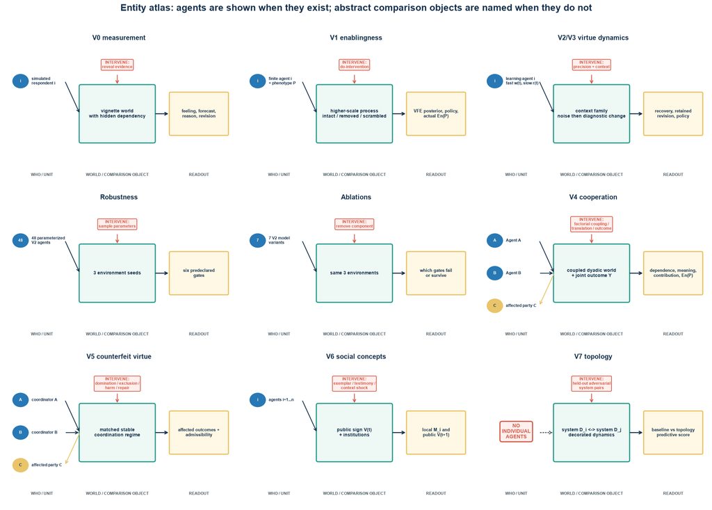

### Why each setup is fit for its question

“Fit” here means that the manipulation creates the contrast required for the limited inference in the final two columns. It does **not** mean that a simulation validates a human construct or supplies the normative bridge.

| Experiment | What literally exists | Manipulation | Measured readout | Why this answers the question | Hard limit |
| --- | --- | --- | --- | --- | --- |
| V0 | Simulated respondent i in a vignette world with reward, approval, expected consequences, hidden enabling facts, and two report times | Separate reports first; reveal hidden evidence later | Whether felt-good reports contain programmed enablingness signal beyond reward/approval and revise after evidence | Temporal separation plus adversarial confounds tests design identifiability | No evidence that humans instantiate the construct |
| V1 | One finite agent with phenotype P embedded in a higher-scale process | Remove or scramble the process; vary priors/preferences while holding the counterfactual target fixed | Actual En(P), inferred process, and policy choice | The intervention defines an independent target, so capture is error relative to something outside the agent estimate | Finite operationalization, not a unique or morally sufficient good |
| V2/V3 | One learning agent with fast practical meaning w(t), slow centre r(t), precision gating, policies, and contextual outcomes | Low-precision noise followed by reliable diagnostic context change and washout | Noise displacement, recovery, retained calibration, retained policy improvement | The same agent must resist non-diagnostic noise yet retain justified revision; rigidity and instability fail different phases | Constructed selective-stability signature, not human virtue |
| Robustness | Forty-eight parameterized copies of the V2 agent in three environment seeds | Sample a declared parameter box | Six V2 gates in every environment | Shows the result is not one hand-picked parameter point inside that box | Does not generalize outside the authored model family |
| Ablations | Seven V2 architectures exposed to the same environments | Remove one proposed component at a time | Change in gate pass rates | Failure identifies architecture-relative necessity; survival rejects necessity in this test | Ablation does not prove unique causal mechanism across all models |
| V4 | Agent A and Agent B with different local frames, a translation channel, causal coupling, joint outcome Y, and affected party C | Factorially vary sign, frame compatibility, coupling, common shock, and affected-party outcome | Dependence, processability, readability, joint attainment, causal contribution, phenotype-indexed En(P) | Orthogonal factors create common-cause, misunderstanding, exploitation, and genuine-coordination cases that one scalar cannot collapse | Setup only until the integrated simulation and ledger exist |
| V5 | Coordinating agents A/B plus affected party C in descriptively matched stable regimes | Vary domination, exclusion, externalized burden, contestability, and repair while matching focal coordination | Affected-party outcomes, exit/voice, burden allocation, repair, admissibility verdict | Matching descriptive success isolates whether the moral bridge detects counterfeit virtue | Normative premises still require philosophical defence |
| V6 | Population of agents i=1...n, local meanings M_i, public sign V(t), and institutional/testimonial channels | Intervene on exemplars, testimony, institutions, contexts, phenotypes, and learning rates | Fast local trajectories, slow public-sign trajectory, uptake and action | Interventions plus competing one-rate/static models test whether the two proposed timescales are real rather than narrated | A successful simulation would not by itself establish historical adequacy |
| V7 | No privileged individual agent: paired decorated dynamical systems D_i and D_j with candidate maps | Use held-out adversarial pairs: same topology/opposed meaning and different topology/equivalent function | Prediction, calibration, invariant preservation, and mapping complexity | Topology must beat semantic and ordinary dynamical baselines on cases designed to expose bare-topology failure | If it ties or loses after complexity penalty, topology is removed |

### V0 — separating felt goodness from its confounds

Each trial temporally separates immediate feeling, expected consequences, social approval, justification, evidence reveal, and later revision. Hidden enabling dependencies let reward and approval disagree with actual consequences.

#### V0 setup diagram

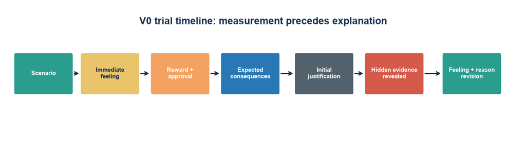

#### V0 result graphs

**Shown because the result is current and reproducible.** The simulation asks whether the planned measurement design can recover distinctions programmed into its own data-generating process. It is a design-recovery test, not evidence that people actually make these distinctions.

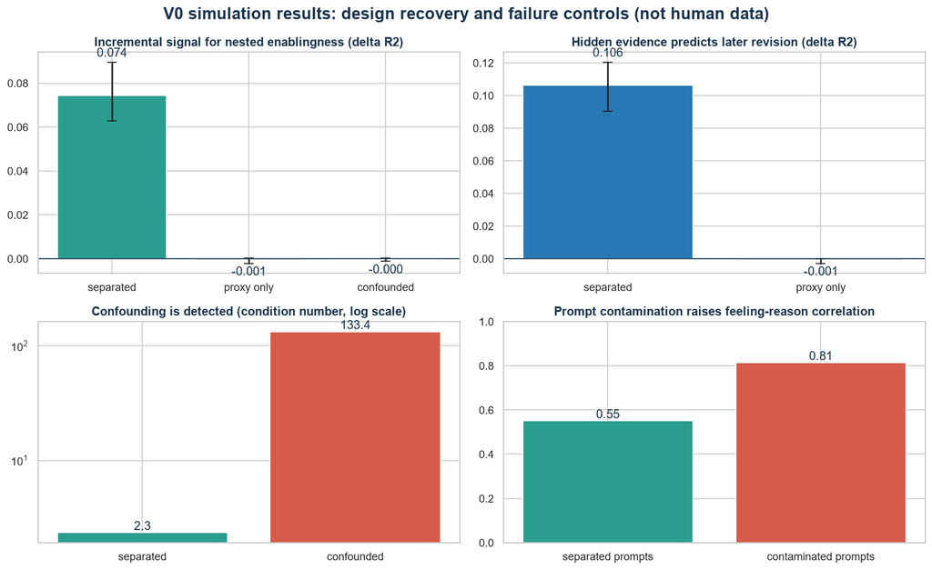

### V1 — counterfactual enablingness and captured active inference

V1 holds the finite world explicit. A higher-scale process is removed or scrambled; phenotype outcomes are recomputed; an agent infers hidden process type via VFE and selects policies via EFE. Reward-dominant preferences and captured priors create predictable miscalibration.

#### V1 setup diagram

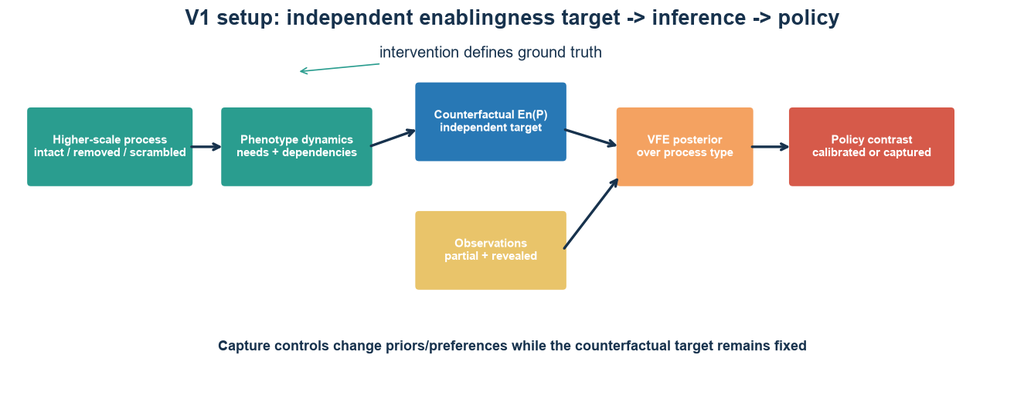

| Layer | Quantity | Purpose |
| --- | --- | --- |
| Ground truth | Counterfactual enabling vector En(P) | Independent simulation intervention |
| Inference | Posterior over hidden process | VFE/Bayesian update |
| Feeling proxy | EFE contrast: reject minus accept | Policy-relative, fallible |
| Failure controls | Captured prior; reward/approval dominance | Can feel good while actual En(P)<0 |
| Crucial reversal | Same process, different phenotype | Goodness is indexed rather than universal |

#### V1 result graphs

**Shown because the result is current and reproducible.** The important result is the dissociation: post-reveal nested signals track the intervention-defined target, captured priors/preferences degrade that calibration, and the same process reverses sign for different phenotypes.

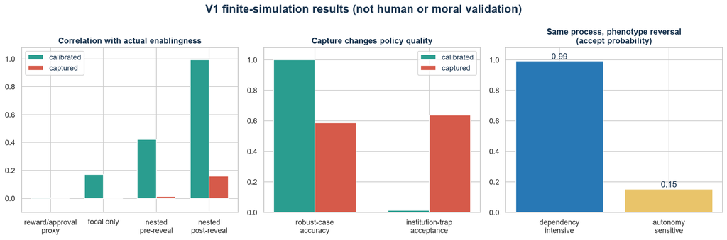

### V2/V3 — selective stability under noise and evidence

The sequence is fixed: settlement, held-out baseline, low-precision perturbation, recovery, diagnostic context change, immediate test, ordinary-context washout, and retained transformed-context test.

#### V2/V3 setup diagram

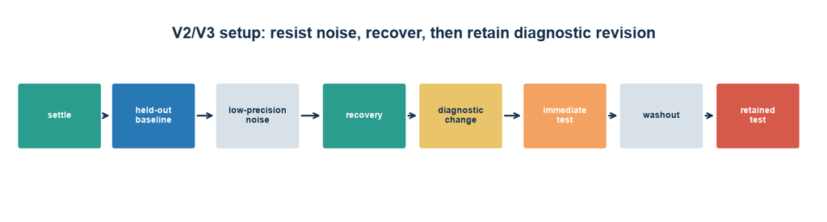

#### V2/V3 regime result graphs

These panels test whether the programmed diagnostics distinguish selective stability from dogmatism, instability, and opportunism.

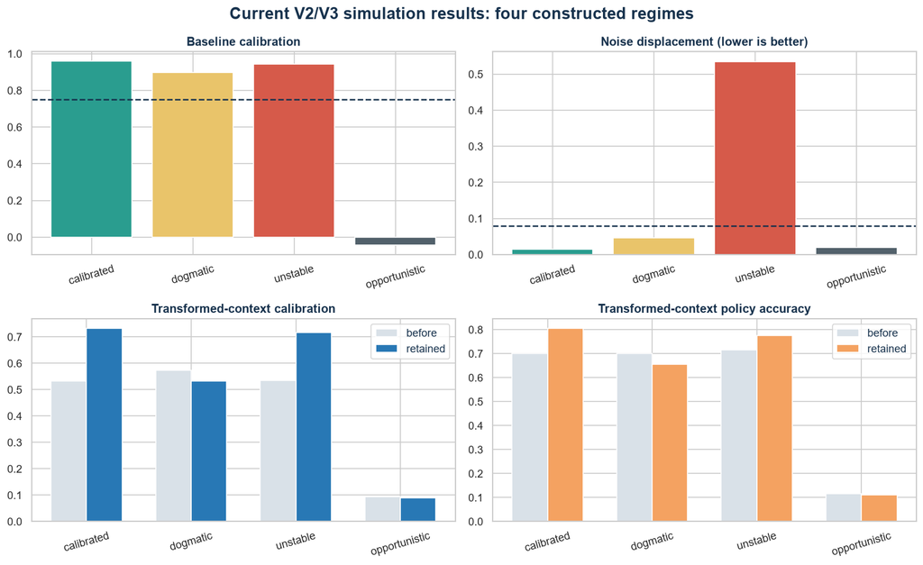

#### V2 robustness result graphs

The sweep asks whether the selective-stability signature survives away from a single hand-authored parameter point.

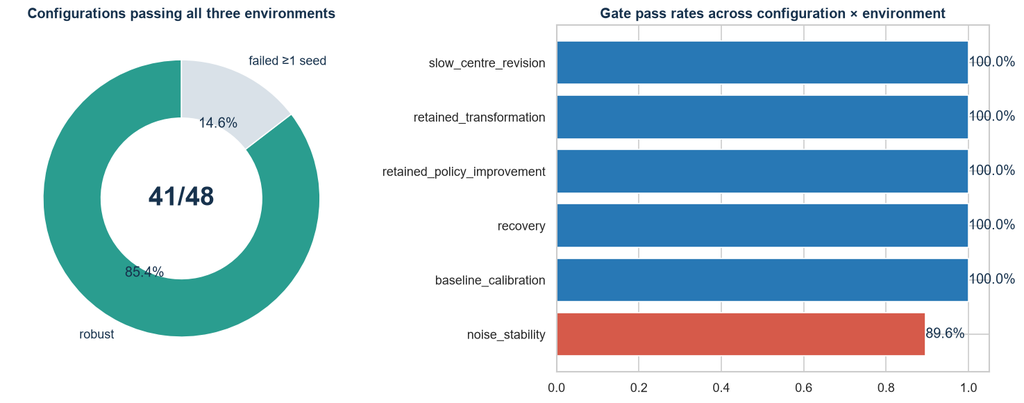

#### V2 mechanism-ablation result

The heatmap asks which proposed components are necessary for the signature inside this architecture.

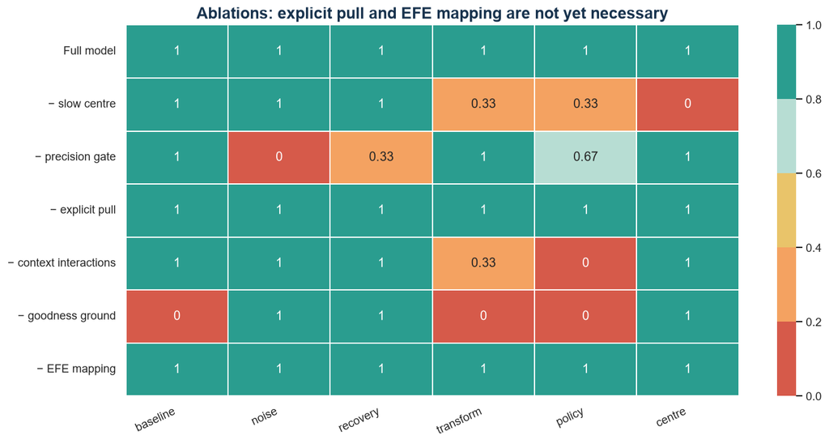

### Why the mechanism-ablation panel matters for virtue

Section 5 of the shorter dashboard is not merely a technical sensitivity check. It asks which parts of the construction earn the right to interpret the simulated regime as **virtue-like**, rather than as generic adaptive control.

| Component | Philosophical work it was meant to do | Ablation result | Consequence for the virtue claim |
| --- | --- | --- | --- |
| Slow-centre learning | Character should persist across situations yet retain genuine learning | Removing it fails | Supports a slow dispositional layer as necessary *in this construction* |
| Evidence-precision gating | Practical wisdom should distinguish noise from trustworthy counterevidence | Removing it fails | Supports selective, not indiscriminate, stability |
| Context interactions | The same virtue may rationally reverse action when consequences change | Removing them fails | Supports context-sensitive practical meaning rather than a fixed rule |
| Goodness grounding | Virtue is a success term, not merely a coherent disposition | Removing it fails | Without calibration to an independent good, the regime cannot count as virtue-like |
| Explicit attraction pull | “Attractor” was proposed as the mechanism of return | Removing it still passes | We cannot claim the explicit pull causes the signature; “attractor” is currently descriptive |
| EFE policy mapping | Active inference was proposed as the distinctive pragmatic bridge | Removing it still passes | EFE is compatible with the result but not yet uniquely explanatory |

Three logical cautions matter:

1. **Failure under ablation is architecture-relative necessity**, not a theorem that every possible virtue must contain that exact parameter.
2. **Survival under ablation refutes necessity for this test.** It prevents us from presenting attractive terminology as an identified cause.
3. **No ablation proves moral sufficiency.** Slow learning, precision gating, context sensitivity, and goodness calibration could still occur in a locally successful but dominating social system. V4 and V5 must test shared consequences and the normative bridge.

The positive virtue mapping is therefore currently:

[figure not shown]

That combination explains why a virtue is stable without being rigid, adaptable without being fickle, context-sensitive without being empty, and good without being defined by the agent's confidence. Whether it is sufficient for **moral** virtue is still open.

### Animation 1 — selective stability (pedagogical one-dimensional projection)

This animation is **not an additional result**. It explains the diagnostic logic in one dimension. Low-quality noise should move an unstable regime but not rewrite a calibrated slow centre. Reliable evidence should transform the calibrated centre but not the dogmatic one.

[figure not shown]

Once Loop Reflect

### V4 — setup only; the next multi-agent experiment has not run

V4 independently randomizes: shared sign, frame compatibility, causal coupling, and affected-party outcome. This creates cases in which dependence, understanding, achievement, and goodness come apart.

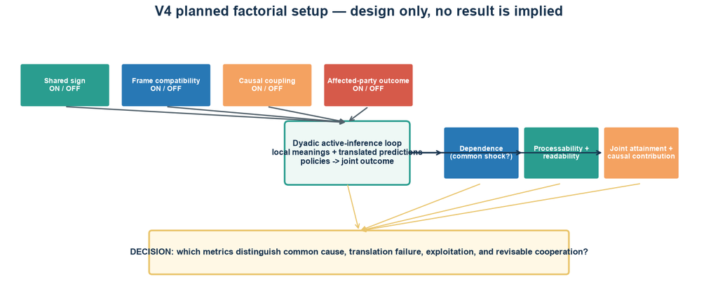

| Case | Dependence | Shared semantics | Joint attainment | Goodness calibration | Purpose |
| --- | --- | --- | --- | --- | --- |
| Common shock | High | Low | Variable | Variable | Dependence ≠ cooperation |
| Different frames / shared meaning | Variable | High | High | High | Translation without convergence |
| Coordinated exploitation | High | High | High focal | Low affected | Coordination ≠ morality |
| Good intention / failed translation | Low | Low | Low | Mixed | Good local orientation can fail jointly |
| Revisable cooperation | High | High | High | Improves | Target virtue signature |

### Animation 2 — shared meaning without identical representations (pedagogical)

Agent A and Agent B use different local codes. A fixed translation channel maps B's anticipation into A's frame. When the context changes, both reverse their practical expectation while remaining mutually translatable. Surface equality is never required.

[figure not shown]

Once Loop Reflect

### V5–V7 — planned setup atlas (designs, not findings)

These experiments have **not run**. Their diagrams make the proposed manipulations, observables, model comparisons, and failure conditions inspectable before any result exists. A future result panel must be generated from a committed ledger; it cannot be substituted by the illustrative arrows below.

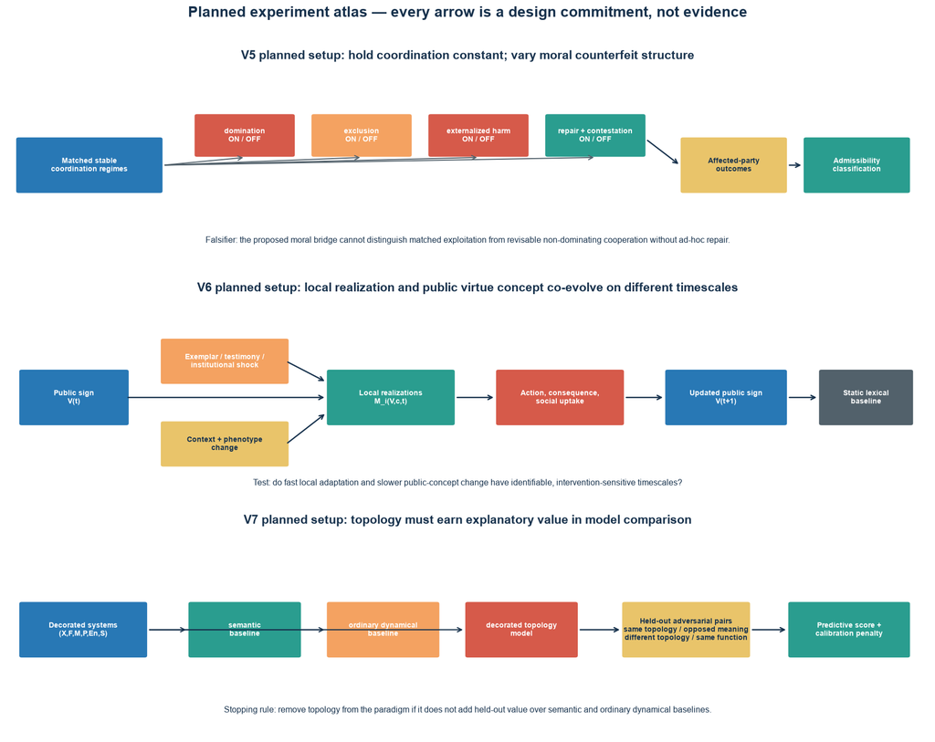

| Experiment | Manipulations | Observables | Required comparison | Decisive failure |
| --- | --- | --- | --- | --- |
| V5 moral counterfeit | Domination, exclusion, externalized burden, repair/contestability while descriptive coordination is matched | Affected-party outcomes, exit/voice, burden distribution, repair | Coordination-only vs explicit moral bridge | Bridge cannot discriminate without case-by-case adjustment |
| V6 concept-realization coevolution | Exemplars, testimony, institutional shocks, contexts, phenotypes, learning rates | Local meaning profiles, actions, uptake, public-sign trajectory | Static lexical vs one-rate vs multi-timescale dynamics | No separable timescales or static model predicts equally well |
| V7 decorated topology | Adversarial system pairs and predeclared invariants | Held-out prediction, calibration, map complexity, invariant preservation | Semantic vs ordinary dynamical vs decorated topology | Topology ties/loses after complexity penalty |

## 7. Formal theorem inventory: what is genuinely machine checked

These theorems are deliberately modest. They verify finite implications and counterexamples from encoded definitions. They do not certify the definitions as adequate moral theory.

| Object | Result / obligation | Status |
| --- | --- | --- |
| Capability dominance | Reflexive, transitive; antisymmetry on capability coordinates | Lean checked |
| Phenotype viability | Policy closure implies finite-horizon viability | Lean checked |
| Recovery | Recovery plus closure implies post-recovery viability | Lean checked |
| Closure ≠ recovery | Finite counterexample theorem | Lean checked |
| Robust dominance | Reflexive and transitive | Lean checked |
| One environment ≠ robust | Finite counterexample theorem | Lean checked |
| Focal benefit ≠ non-externalization | Affected-floor counterexample theorem | Lean checked |
| Relative moral-goodness predicate | Projection lemmas to admissibility/plural/procedural fields | Lean checked, conditional |
| Action influence ≠ reachability | Finite solver counterexample | Z3 checked |
| Metric/pseudometric for alignment | Triangle, identity, symmetry as applicable | Not started |
| Decorated map composition | Identity, composition, invariant preservation | Not started |

## 8. Cross-project division of labour

The other repositories supply mechanisms and tasks; this repository supplies the goodness calibration target and keeps descriptive coordination separate from moral admissibility.

| Project | Contribution | Use here |
| --- | --- | --- |
| topological-alignment | Phenotype goodness, virtue calibration, normative bridge | Integration layer |
| shared-protention-alignment | Processability, channels, sheaf gluing | V4 shared semantics |
| externalization-horizon | Observability and reciprocal readability | V4 legibility |
| empathy-prisonner-dilemma | Joint outcomes and exploitability | First V4 environment |
| Active_Inference_Social_Lock_In | Stable social lock-in and precision dynamics | Counterfeit-attractor control |
| group-formation/tom | Shared scripts and post-shock group identity | V6 social dynamics |
| aif-meta-cogames | Roles, strangers, ecological complementarity | Later generalization |

## 9. Experiment roadmap and stopping rules

| Stage | Primary claim | Decisive result | Stop / rethink if |
| --- | --- | --- | --- |
| V0 | Felt goodness is separable and fallible | temporal/causal identification beyond reward and approval | construct is not separable |
| V1 | Enablingness can ground calibration | counterfactual and phenotype reversals | target is intervention-fragile or tautological |
| V2/V3 | Virtue has selective-stability signature | recovery + retained diagnostic revision | simpler models explain it; no dissociation |
| **V4 next** | Shared meaning and cooperation are joint/relational | factorial dissociations + causal coupling | processability/readability add no value |
| V5 | Stable coordination can be morally counterfeit | matched exploitation/domination cases | moral bridge cannot discriminate non-ad-hocly |
| V6 | Public concepts and local realizations co-evolve | separable timescales + intervention response | static lexical model wins |
| V7 | Decorated topology adds value | held-out advantage on adversarial pairs | semantic/dynamical baselines tie or win |

## 10. The strongest honest conclusion today

**Supported inside the declared simulation family:** selective semantic stability occupies a broad sampled parameter region and depends, under tested ablations, on slow-centre learning, evidence-precision gating, context-sensitive meaning, and goodness-grounding.

**Not established:** that an explicit attraction term is necessary; that EFE is uniquely necessary; that the model describes human virtue; that phenotype-relative enablingness by itself is moral goodness; that shared semantics or cooperation has already been integrated; or that topology adds predictive value.

The immediate task is therefore **V4**, not another attractive philosophical label: one identified multi-agent model in which shared signs, translated expectations, causal coupling, joint consequences, affected-party enablingness, and revision after hidden harm are generated and tested together.

### Canonical supporting documents

- `docs/MULTISCALE_GOODNESS_AND_VIRTUE_ATTRACTORS.md`
- `docs/PARADIGM_PROOF_OBLIGATIONS.md`
- `docs/ACTIVE_INFERENCE_NORMATIVE_FORMALIZATION.md`
- `docs/MORAL_GOODNESS_ACTIVE_INFERENCE_TRANSLATION.md`
- `docs/SUPPORTED_REPLACEMENTS_LEDGER.md`
- `docs/V2_VIRTUE_ATTRACTOR_CALIBRATION_SIMULATION.md`
- `docs/CROSS_PROJECT_INTEGRATION_ASSESSMENT_2026-07-20.md`
- `formal/THEOREM_LEDGER.md`